# Informality data overview, Bolivia

ARU Foundation

Julio, 2020

# Sobre Formalidad

## Primera definición (de jure)

La primera aproximación se la realiza empleado una definción de jure. Así, son considerados formales:

- Trabajadores asalariados quienes tengan almenos 3 de los siguientes benficios:
  - Aguinaldo
  - Seguridad social de largo plazo (Afiliación a una AFP)
  - Seguridad social de corto plazo (Seguro de salud dotado por el empleador)
  - Vacaciones
  - Otros beneficios (Basa en la pregunta en la ECE)

El resto de los trabajadores son considerados informales

### Tabulados

#### Mensual

| year | month | bol_i | bol_f | urb_i | urb_f | rur_i | rur_f |
| --- | --- | --- | --- | --- | --- | --- | --- |
| 2015 | 10 | 82.42894 | 17.57106 | 76.23756 | 23.76244 | 93.75198 | 6.248017 |
| 2015 | 11 | 80.34803 | 19.65197 | 73.72318 | 26.27682 | 92.05084 | 7.949156 |
| 2015 | 12 | 81.13390 | 18.86610 | 73.92234 | 26.07766 | 93.74038 | 6.259623 |
| 2016 | 1 | 81.01403 | 18.98597 | 73.87214 | 26.12786 | 94.14352 | 5.856485 |
| 2016 | 2 | 78.98774 | 21.01226 | 71.90073 | 28.09927 | 92.71862 | 7.281383 |
| 2016 | 3 | 80.18864 | 19.81136 | 71.94728 | 28.05272 | 95.09288 | 4.907124 |
| 2016 | 4 | 81.00255 | 18.99745 | 74.94675 | 25.05325 | 91.82491 | 8.175090 |
| 2016 | 5 | 81.13309 | 18.86691 | 74.04713 | 25.95287 | 93.92676 | 6.073243 |
| 2016 | 6 | 81.38073 | 18.61927 | 74.29636 | 25.70364 | 93.64391 | 6.356086 |
| 2016 | 7 | 82.45306 | 17.54694 | 76.40605 | 23.59395 | 93.53843 | 6.461570 |

[output cut: 38 more lines]

#### Trimestral

| year | quarter | bol_i | bol_f | urb_i | urb_f | rur_i | rur_f |
| --- | --- | --- | --- | --- | --- | --- | --- |
| 2016 | 1 | 80.09913 | 19.90087 | 72.70789 | 27.29211 | 93.89165 | 6.108348 |
| 2016 | 2 | 81.16853 | 18.83147 | 74.48246 | 25.51754 | 93.08721 | 6.912786 |
| 2016 | 3 | 82.27827 | 17.72173 | 75.85540 | 24.14460 | 93.92110 | 6.078903 |
| 2016 | 4 | 82.67912 | 17.32088 | 76.02099 | 23.97901 | 94.57190 | 5.428099 |
| 2017 | 1 | 82.93413 | 17.06587 | 76.15730 | 23.84270 | 94.72716 | 5.272841 |
| 2017 | 2 | 82.92150 | 17.07850 | 76.75072 | 23.24928 | 93.84478 | 6.155220 |
| 2017 | 3 | 83.28851 | 16.71149 | 76.92880 | 23.07120 | 94.65616 | 5.343839 |
| 2017 | 4 | 84.13552 | 15.86448 | 78.12473 | 21.87527 | 95.09724 | 4.902765 |
| 2018 | 1 | 84.12160 | 15.87840 | 78.00504 | 21.99496 | 95.24250 | 4.757497 |
| 2018 | 2 | 84.16822 | 15.83178 | 77.81410 | 22.18590 | 95.48136 | 4.518639 |

[output cut: 5 more lines]

### Visualización

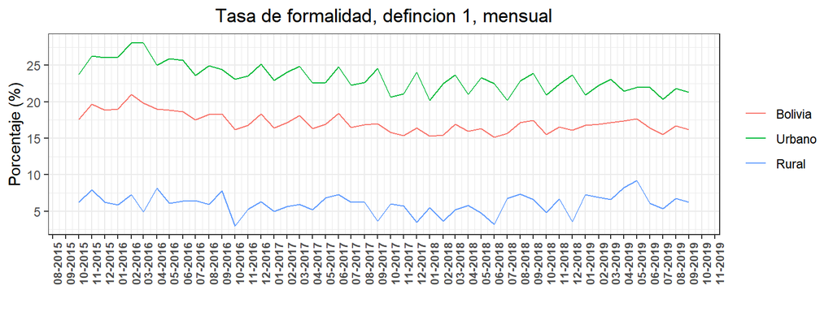

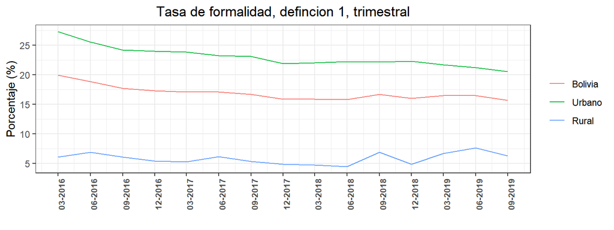

## Segunda definición (Hibrida: sector y empleo informal)

Se aproxima la condicion de formalidad del empleo haciendo la división siguiente:

- Asalariados
  - En el sector público
    - Todos son considerados formales
  - En el sector privado
    - Formales
      - Trabajadores con afiliación a seguridad social de largo plazo (AFP)
      - Trbajadores sin afilación a seguridad social de largo plazo; pero, con seguridad social de corto plazo brinda por el empleador
      - Trabajadores sin afiliación a seguridad social ni de corto ni de largo plazo pero con almenos 2 de los siguientes beneficios: a) contrato firmado, b) Aguinaldo, c) Vacaciones y d) Otros beneficios
    - El resto de los asalariados en el sector privado es considerado informal
- No asalariados
  - Empresarios
    - Formales si su unidad económica tiene registro tributario en el régimen general
  - Cuenta propias
    - Formales si su unidad económica tiene registro tributario en el régimen general
  - El resto de los trabajadores no-asalariados son considerados informales

### Tabulados

#### Mensual

| year | month | bol_i | bol_f | urb_i | urb_f | rur_i | rur_f |
| --- | --- | --- | --- | --- | --- | --- | --- |
| 2015 | 10 | 79.79197 | 20.20803 | 72.62319 | 27.37681 | 92.90253 | 7.097474 |
| 2015 | 11 | 77.85022 | 22.14978 | 70.06846 | 29.93154 | 91.59671 | 8.403290 |
| 2015 | 12 | 78.54187 | 21.45813 | 70.13044 | 29.86956 | 93.24581 | 6.754190 |
| 2016 | 1 | 78.68853 | 21.31147 | 70.51828 | 29.48172 | 93.70854 | 6.291461 |
| 2016 | 2 | 76.25364 | 23.74636 | 68.08387 | 31.91613 | 92.08235 | 7.917650 |
| 2016 | 3 | 77.04977 | 22.95023 | 67.69064 | 32.30936 | 93.97543 | 6.024570 |
| 2016 | 4 | 77.97372 | 22.02628 | 70.68282 | 29.31718 | 91.00334 | 8.996656 |
| 2016 | 5 | 78.05930 | 21.94070 | 69.52811 | 30.47189 | 93.46233 | 6.537674 |
| 2016 | 6 | 77.44921 | 22.55079 | 68.54075 | 31.45925 | 92.86991 | 7.130091 |
| 2016 | 7 | 78.28761 | 21.71239 | 70.52501 | 29.47499 | 92.51798 | 7.482020 |

[output cut: 38 more lines]

#### Trimestral

| year | quarter | bol_i | bol_f | urb_i | urb_f | rur_i | rur_f |
| --- | --- | --- | --- | --- | --- | --- | --- |
| 2016 | 1 | 77.40000 | 22.60000 | 68.94075 | 31.05925 | 93.18550 | 6.814501 |
| 2016 | 2 | 77.85585 | 22.14415 | 69.68507 | 30.31493 | 92.42121 | 7.578792 |
| 2016 | 3 | 78.11443 | 21.88557 | 69.97261 | 30.02739 | 92.87322 | 7.126776 |
| 2016 | 4 | 78.74148 | 21.25852 | 70.30495 | 29.69505 | 93.81084 | 6.189158 |
| 2017 | 1 | 79.05030 | 20.94970 | 70.43966 | 29.56034 | 94.03452 | 5.965478 |
| 2017 | 2 | 78.80885 | 21.19115 | 70.78038 | 29.21962 | 93.02053 | 6.979473 |
| 2017 | 3 | 79.26695 | 20.73305 | 70.96153 | 29.03847 | 94.11246 | 5.887544 |
| 2017 | 4 | 79.81942 | 20.18058 | 71.94664 | 28.05336 | 94.17680 | 5.823203 |
| 2018 | 1 | 80.58749 | 19.41251 | 72.89007 | 27.10993 | 94.58264 | 5.417359 |
| 2018 | 2 | 79.94675 | 20.05325 | 71.56927 | 28.43073 | 94.86236 | 5.137636 |

[output cut: 5 more lines]

### Visualización

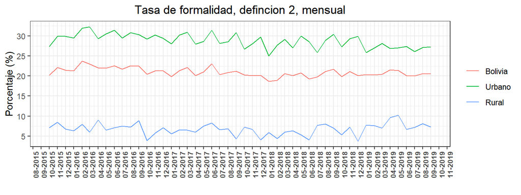

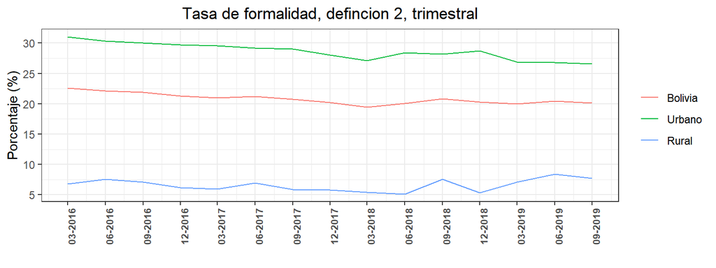

## Tercera definición (Sector y tamaño de firma)

Se define como trabajadores informales a aquellos trabajadores asalariados, patrones, socios o cooperativistas del sector semi-empresarial que realizan alguna actividad económica en firmas o en instituciones compuestas por menos de cinco empleados, trabajadores por cuenta propia y a los trabajadores familiares (no incluye trabajo doméstico).

### Tabulados

.

#### Mensual

| year | month | bol_i | bol_f | urb_i | urb_f | rur_i | rur_f |
| --- | --- | --- | --- | --- | --- | --- | --- |
| 2015 | 10 | 77.85133 | 22.14867 | 69.32493 | 30.67507 | 92.25235 | 7.747654 |
| 2015 | 11 | 76.42097 | 23.57903 | 68.65310 | 31.34690 | 89.28113 | 10.718868 |
| 2015 | 12 | 76.28890 | 23.71110 | 68.81272 | 31.18728 | 91.31596 | 8.684038 |
| 2016 | 1 | 78.11400 | 21.88600 | 70.74616 | 29.25384 | 91.18632 | 8.813685 |
| 2016 | 2 | 76.46716 | 23.53284 | 69.41534 | 30.58466 | 90.17500 | 9.825002 |
| 2016 | 3 | 77.09448 | 22.90552 | 69.31561 | 30.68439 | 92.00656 | 7.993437 |
| 2016 | 4 | 79.69781 | 20.30219 | 72.67437 | 27.32563 | 91.89879 | 8.101212 |
| 2016 | 5 | 77.09798 | 22.90202 | 69.01149 | 30.98851 | 91.34783 | 8.652169 |
| 2016 | 6 | 76.06789 | 23.93211 | 68.52696 | 31.47304 | 90.12242 | 9.877584 |
| 2016 | 7 | 77.23063 | 22.76937 | 70.26398 | 29.73602 | 89.83627 | 10.163727 |

[output cut: 38 more lines]

#### Trimestral

| year | quarter | bol_i | bol_f | urb_i | urb_f | rur_i | rur_f |
| --- | --- | --- | --- | --- | --- | --- | --- |
| 2016 | 1 | 77.31330 | 22.68670 | 69.90527 | 30.09473 | 91.13727 | 8.862732 |
| 2016 | 2 | 77.79943 | 22.20057 | 70.28003 | 29.71997 | 91.20241 | 8.797594 |
| 2016 | 3 | 77.45929 | 22.54071 | 70.17528 | 29.82472 | 90.66976 | 9.330237 |
| 2016 | 4 | 77.15217 | 22.84783 | 68.98954 | 31.01046 | 91.73493 | 8.265067 |
| 2017 | 1 | 77.63991 | 22.36009 | 69.44065 | 30.55935 | 91.91203 | 8.087967 |
| 2017 | 2 | 77.40100 | 22.59900 | 69.87987 | 30.12013 | 90.71460 | 9.285398 |
| 2017 | 3 | 77.72303 | 22.27697 | 69.78278 | 30.21722 | 91.91706 | 8.082938 |
| 2017 | 4 | 78.18530 | 21.81470 | 70.28524 | 29.71476 | 92.59246 | 7.407542 |
| 2018 | 1 | 79.95708 | 20.04292 | 72.43242 | 27.56758 | 93.64058 | 6.359420 |
| 2018 | 2 | 78.59810 | 21.40190 | 70.28738 | 29.71262 | 93.39486 | 6.605142 |

[output cut: 5 more lines]

### Visualización

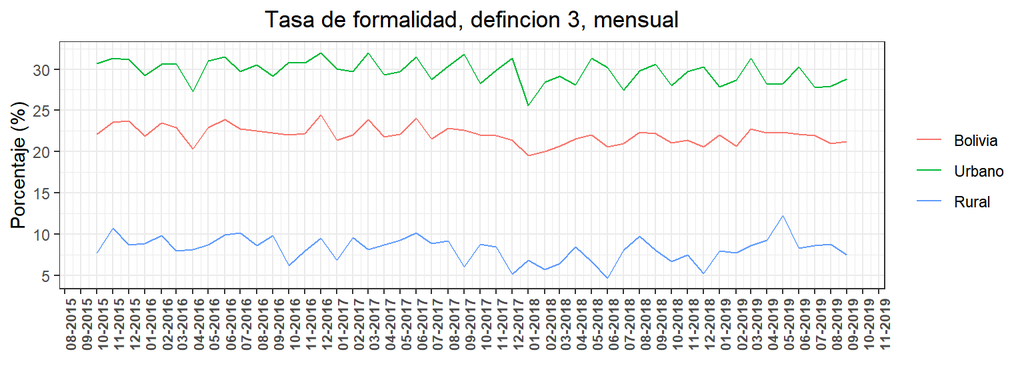

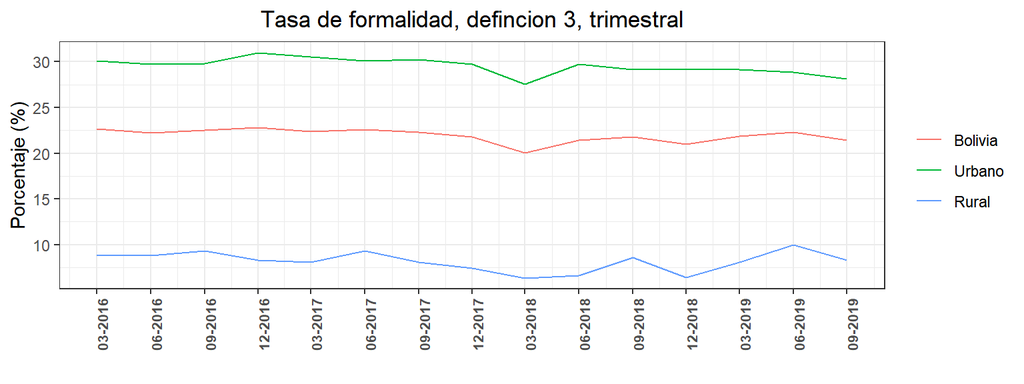

## Comparación en areas urbanas

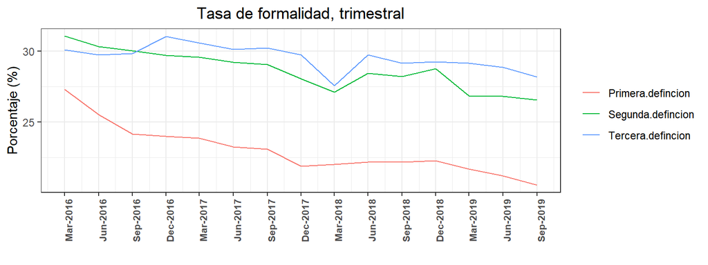